# Practical machine learning course project

Rafael Castrillo

This document presents the model used to predict the way a barbell lift was performed, based on data from accelerometers on the belt, forearm, arm, and dumbell for six test participants. The data is available in the website: http://groupware.les.inf.puc-rio.br/har.

First of all, the data was read from the working directory. The dataset is high dimensional, and includes 19622 observations for different repeats of weight lifting. The original authors focused on the summary statistics of each weight lift, and thus there are several variables in the data that only have values for the last observation in each “cycle”. For this model, we will only use the actual accelerometer readings, so we removed the variables that included summary statistics.

```r
setwd("~/data/Machine Learning")
train<-read.csv("pml-training.csv",na.string=c("#DIV/0!","","NA"),row.names=1)
test<-read.csv("pml-testing.csv",na.string=c("#DIV/0!","","NA"),row.names=1)
na<-apply(train,2,function(x){sum(is.na(x))})
train<-train[,na==0]
train<-train[,-c(2:7)]
```

In this case, we won’t create a separate testing set, so we will use cross validation to estimate the testing error.

We proceded to train several models, including CART, knn and random forest. The last two provided the most promissing results, and we ended up choosing the random forest model for this assignment.

The model was generated using the caret package, and train control was done using 10-fold cross validation. This would be equivalent to taking 10 different partitions of the data and using in turn 1 as the test set.The algorithm was slow to converge, so we used 200 trees to speed up the process a bit.

```r
set.seed(1989)
library(caret)
ctrl<-trainControl(method="cv",number=10)
mod1<-train(classe~.,data=train,method="knn",trControl=ctrl)
mod2<-train(classe~.,data=train,method="rf",trControl=ctrl,ntrees=200)
```

The results of the training process can be summarized below, for both the knn model and the random forest model:

### K-nearest neighbor model

```r
mod1
```

```
## k-Nearest Neighbors
##
## 19622 samples
##    52 predictor
##     5 classes: 'A', 'B', 'C', 'D', 'E'
##
## No pre-processing
## Resampling: Cross-Validated (10 fold)
##
## Summary of sample sizes: 17659, 17660, 17659, 17660, 17659, 17661, ...
##
## Resampling results across tuning parameters:
##
##   k  Accuracy   Kappa      Accuracy SD  Kappa SD
##   5  0.9315055  0.9133230  0.005739899  0.007275642
##   7  0.9114251  0.8879122  0.006051922  0.007653590
##   9  0.8944544  0.8664057  0.006738545  0.008541547
##
## Accuracy was used to select the optimal model using  the largest value.
## The final value used for the model was k = 5.
```

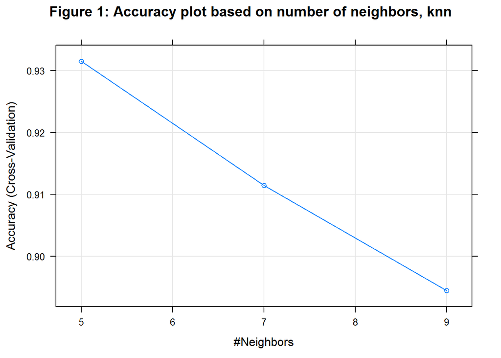

```r
plot(mod1,main="Figure 1: Accuracy plot based on number of neighbors, knn")
```

Using the optimal 5 nearest neighbor rule, our expected test-set accuracy of the model in the test set is of about 0.93.

### Random forest model

```r
mod2
```

```
## Random Forest
##
## 19622 samples
##    52 predictor
##     5 classes: 'A', 'B', 'C', 'D', 'E'
##
## No pre-processing
## Resampling: Cross-Validated (10 fold)
##
## Summary of sample sizes: 17659, 17658, 17660, 17660, 17660, 17661, ...
##
## Resampling results across tuning parameters:
##
##   mtry  Accuracy   Kappa      Accuracy SD  Kappa SD
##    2    0.9942922  0.9927795  0.001826274  0.002310547
##   29    0.9953626  0.9941337  0.002001345  0.002531486
##   56    0.9921009  0.9900074  0.002306583  0.002917527
##
## Accuracy was used to select the optimal model using  the largest value.
## The final value used for the model was mtry = 29.
```

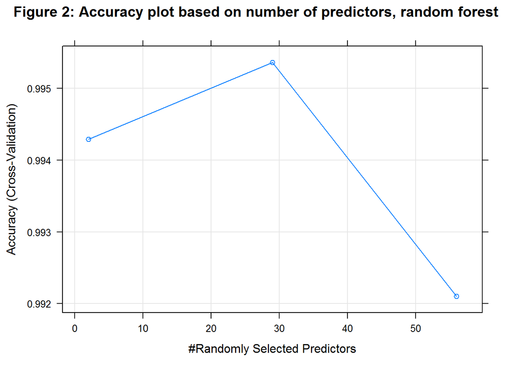

```r
plot(mod2,main="Figure 2: Accuracy plot based on number of predictors, random forest")
```

In this case, the expected test set accuracy of the model based on the 10-fold cross-validation is of 0.995.

We can now check the results of our model on the training set.

```r
preds<-predict(mod2$finalModel,type="class")
tab<-prop.table(table(preds,train$classe))
tab
```

```
##
## preds            A            B            C            D            E
##     A 0.2841708287 0.0010192641 0.0000000000 0.0000000000 0.0000000000
##     B 0.0001528896 0.1920803180 0.0005605953 0.0000000000 0.0000000000
##     C 0.0000000000 0.0003057792 0.1734787483 0.0010702273 0.0001019264
##     D 0.0000000000 0.0000000000 0.0003567424 0.1626745490 0.0001528896
##     E 0.0000509632 0.0001019264 0.0000000000 0.0001528896 0.1835694628
```

```r
sum(diag(tab))
```

```
## [1] 0.9959739
```

The results above point us to a 99.6% accuracy on the training set.